# EP01-respuesta-equipo-7

Edad de la jefatura de hogar según sexo en la Región Metropolitana

## Pregunta

**¿A qué edad se es jefa o jefe de hogar en la Región Metropolitana, y es distinto para hombres y mujeres?**

## Carga de datos

```r
library(tidyverse)

casen_rm <- read_csv(
  "EP01-Datos-Casen2024-RM.csv",
  na = c("", "NA"),
  col_types = cols(
    folio          = col_character(),
    provincia      = col_factor(),
    comuna         = col_factor(),
    area           = col_factor(),
    edad           = col_double(),
    sexo           = col_factor(),
    ecivil         = col_factor(),
    nivel_educ     = col_factor(),
    h_trab_sem     = col_double(),
    tipo_trab      = col_factor(),
    ing_aut_hogar  = col_double(),
    num_pers_hogar = col_double()
  )
)
```

Usaremos las variables edad y sexo. edad es una variable numérica discreta que indica los años de la jefa o jefe de hogar. sexo es una variable categórica nominal con las categorías Hombre y Mujer, que nos permitirá comparar sus edades. No utilizaremos las demás variables porque no son necesarias para responder directamente la pregunta.

## Estadísticos

Calculamos la cantidad de hogares para conocer el tamaño de cada grupo. La media y la mediana resumen la edad central. La desviación estándar y el rango intercuartílico muestran cuánto varían las edades dentro de cada grupo.

```r
resumen <- casen_rm |>
  group_by(sexo) |>
  summarise(
    hogares = n(),
    media = mean(edad, na.rm = TRUE),
    mediana = median(edad, na.rm = TRUE),
    desviacion_estandar = sd(edad, na.rm = TRUE),
    q1 = quantile(edad, 0.25, na.rm = TRUE),
    q3 = quantile(edad, 0.75, na.rm = TRUE)
  )

resumen_mostrar <- resumen |>
  mutate(
    media = round(media, 1),
    desviacion_estandar = round(desviacion_estandar, 1)
  ) |>
  rename(
    Sexo = sexo,
    Hogares = hogares,
    Media = media,
    Mediana = mediana,
    `Desviación estándar` = desviacion_estandar,
    Q1 = q1,
    Q3 = q3
  )

knitr::kable(
  resumen_mostrar,
  caption = "Edad de la jefatura de hogar según sexo"
)
```

Edad de la jefatura de hogar según sexo

| Sexo | Hogares | Media | Mediana | Desviación estándar | Q1 | Q3 |
| --- | --- | --- | --- | --- | --- | --- |
| Hombre | 6552 | 52.9 | 53 | 16.0 | 40 | 65 |
| Mujer | 7599 | 53.4 | 53 | 16.4 | 40 | 66 |

## Gráfico

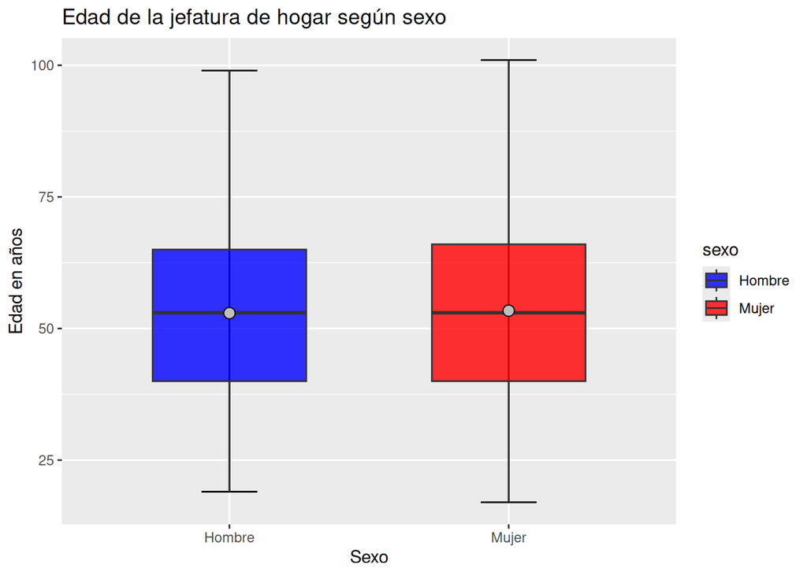

```r
ggplot(casen_rm, aes(x = sexo, y = edad, fill = sexo)) +
  stat_boxplot(geom = "errorbar", width = 0.2) +
  geom_boxplot(width = 0.55, alpha = 0.8, outlier.alpha = 0.35) +
  stat_summary(
    fun = mean,
    geom = "point",
    shape = 21,
    size = 3,
    fill = "gray"
  ) +
  scale_fill_manual(values = c("Hombre" = "blue", "Mujer" = "red")) +
  labs(
    title = "Edad de la jefatura de hogar según sexo",
    x = "Sexo",
    y = "Edad en años"
  )
```

## Descripción del gráfico

Las cajas de hombres y mujeres se encuentran a alturas muy parecidas y se superponen ampliamente. La mediana es de 53 años en ambos grupos. El 50% central de las edades se encuentra entre 40 y 65 años en los hombres y entre 40 y 66 años en las mujeres. Las mujeres tienen una media levemente mayor, pero la diferencia es pequeña en comparación con la dispersión de las edades.

## Respuesta

En esta muestra, se es jefa o jefe de hogar aproximadamente a los 53 años. No observamos una diferencia importante entre hombres y mujeres: ambos grupos tienen la misma mediana y presentan distribuciones muy similares. La media de las mujeres es solo cerca de medio año mayor que la de los hombres.

Estas conclusiones describen los hogares incluidos en el archivo. Como la base entregada no contiene un ponderador muestral, no podemos generalizarlas automáticamente a todos los hogares de la Región Metropolitana.